# Анализ посещаемости Яндекс.Поиска по данным LiveInternet

Для начала найдем статистику посещаемости **Яндекс.Поиска** на сайте **LiveInternet**. Собственно, статистику по переходам на другие сайты из поисковых систем можно найти по ссылке http://www.liveinternet.ru/stat/ru/searches.html.

Под посещаемостью Яндекс.Поиска будем подразумевать количество переходов из него на другие сайты. Последние доступные данные по среднесуточной посещаемости: 10 мая - 3 декабря 2015. Также будем анализировать понедельные данные о суммарном количестве переходов. Скачаем их в формате **.csv**. Для анализа будем использовать язык **R** и **R Studio**.

## Анализ

Загрузим данные в R Studio:

```r
# per day
search <- read.csv("searches.csv", header = T, sep = ";")
head(search)
```

```
##         Date    Yandex
## 1 2015-05-10  97862676
## 2 2015-05-17 104294297
## 3 2015-05-24 105373180
## 4 2015-05-31 102144261
## 5 2015-06-07 100496306
## 6 2015-06-14  94901826
```

```r
# week summary
search.week <- read.csv("searches_week.csv", header = T, sep = ";")
head(search.week)
```

```
##         Date    Yandex
## 1 2015-05-10 685038734
## 2 2015-05-17 730060077
## 3 2015-05-24 737612259
## 4 2015-05-31 715009825
## 5 2015-06-07 703474145
## 6 2015-06-14 664312783
```

Построим графики:

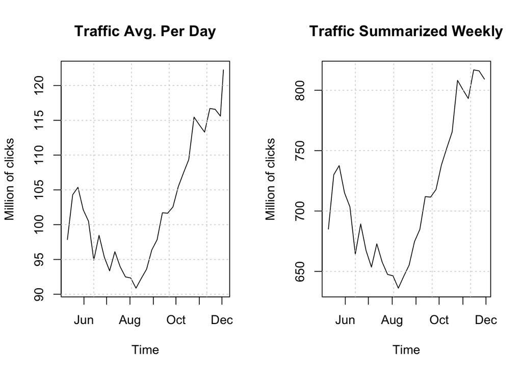

```r
par(mfrow = c(1, 2))
search$Date <- as.Date(search$Date)
search.week$Date <- as.Date(search.week$Date)
plot(search$Date, search$Yandex / 10^6, type = "l", xlab = "Time", ylab = "Million of clicks", main = "Traffic Avg. Per Day")
grid()
plot(search.week$Date, search.week$Yandex / 10^6, type = "l", xlab = "Time", ylab = "Million of clicks", main = "Traffic Summarized Weekly")
grid()
```

Как видно из графика, с 24 мая количество переходов из Яндекс.Поиска постепенно уменьшалось (со скачками), а, начиная со второй недели августа, наоборот, начало существенно расти и к последней рассматриваемой неделе составила 122 млн. 245 тыс. переходов, что составляет 50% среди всех поисковиков. Наименьшее среднесуточное количество переходов, по данным LiveInternet, было зафиксировано во вторую неделю августа - 90 млн. 872 тыс. переходов.

Что касается общего количество переходов за неделю, то здесь ситуация подобна среднесуточной статистики: с 9 по 15 августа был достигнут минимум за весь рассматриваемый период - 636 млн. 107 тыс. переходов, а затем снова начался быстрый рост и к концу ноября количество переходов достигло 809 млн. 225 тыс.

## Закономерности

Для того, чтобы не искать закономерности и аномалии вручную по графику, попробуем автоматизировать данный процесс.

Одним из нестандартных, но, в то же время, довольно эффективных способов поиска и визуализации **закономерностей** являются **регулярные выражения**.

Переведем наши данные в последовательность нулей и единиц, где 1 означает, что количество переходов в данную неделю возросло, а 0 - нет.

```r
delta <- (sign(diff(search$Yandex)) == 1) + 0
delta2 <- (sign(diff(search.week$Yandex)) == 1) + 0
head(delta)
```

```
## [1] 1 1 0 0 0 1
```

```r
head(delta2)
```

```
## [1] 1 1 0 0 0 1
```

Регулярные выражения работают со строками, а не векторами, так что сделаем из данного бинарного вектора одну строку:

```r
delta.str <- do.call(paste0, as.list(c(delta)))
delta.str
```

```
## [1] "110001001000011111011111001001"
```

```r
delta2.str <- do.call(paste0, as.list(c(delta2)))
delta2.str
```

```
## [1] "11000100100001111101111100100"
```

Будем считать временной интервал положительной зависимостью, если количество переходов возрастало хотя бы две недели подряд, а отрицательной - если, наоборот, уменьшалось.

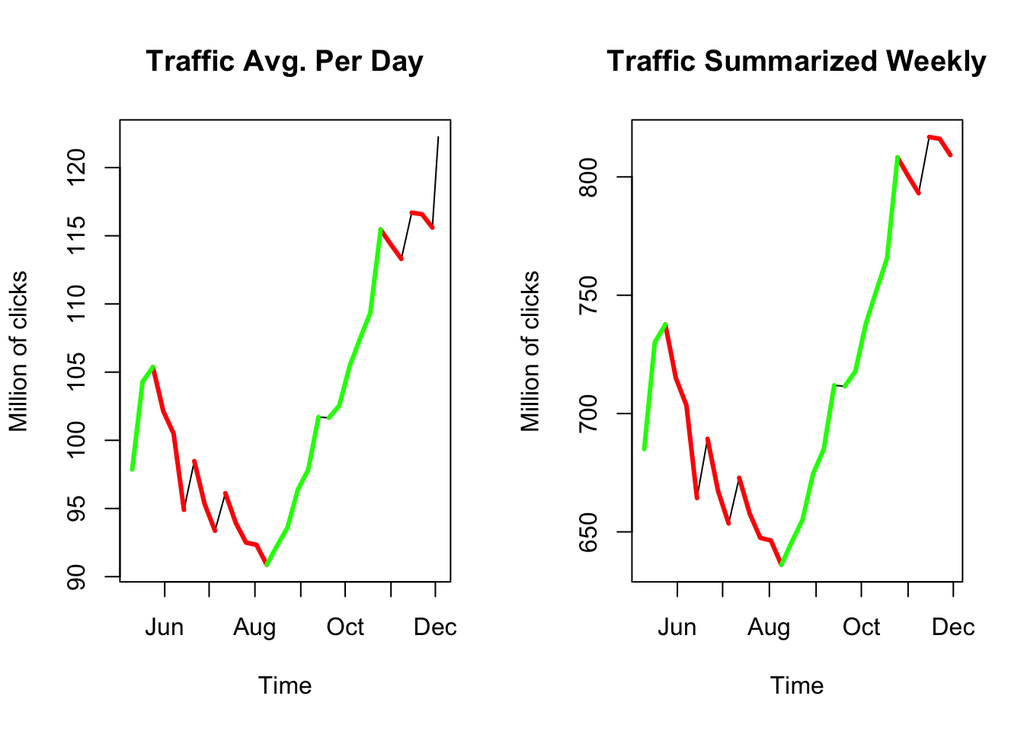

```r
matches.rec <- gregexpr("00+", delta.str, perl = T)[[1]]
matches2.rec <- gregexpr("00+", delta2.str, perl = T)[[1]]
matches.inc <-  gregexpr("11+", delta.str, perl = T)[[1]]
matches2.inc <-  gregexpr("11+", delta2.str, perl = T)[[1]]
m.length.rec = attr(matches.rec,"match.length")
m.length.rec2 = attr(matches2.rec,"match.length")
m.length.inc = attr(matches.inc,"match.length")
m.length.inc2 = attr(matches2.inc,"match.length")

recessions <- sapply(1:length(matches.rec), function(ind) matches.rec[ind]+0:(m.length.rec[ind]))
increases <- sapply(1:length(matches.inc), function(ind) matches.inc[ind]+0:(m.length.inc[ind]))
recessions2 <- sapply(1:length(matches2.rec), function(ind) matches2.rec[ind]+0:(m.length.rec2[ind]))
increases2 <- sapply(1:length(matches2.inc), function(ind) matches2.inc[ind]+0:(m.length.inc2[ind]))

hl = function(inds) lines(search$Date[inds], search$Yandex[inds] / 10^6, col = "red", lwd = 3)
hl2 = function(inds) lines(search$Date[inds], search$Yandex[inds] / 10^6, col = "green", lwd = 3)
wl = function(inds) lines(search.week$Date[inds], search.week$Yandex[inds] / 10^6, col = "red", lwd = 3)
wl2 = function(inds) lines(search.week$Date[inds], search.week$Yandex[inds] / 10^6, col = "green", lwd = 3)

par(mfrow = c(1, 2))
plot(search$Date, search$Yandex  / 10^6, type = "l", xlab = "Time", ylab = "Million of clicks", main = "Traffic Avg. Per Day")
tmp = sapply(recessions, hl)  #Used for side-effects only
tmp2 = sapply(increases, hl2)  #Used for side-effects only
plot(search.week$Date, search.week$Yandex / 10^6, type = "l", xlab = "Time", ylab = "Million of clicks", main = "Traffic Summarized Weekly")
tmp = sapply(recessions2, wl)  #Used for side-effects only
tmp2 = sapply(increases2, wl2)  #Used for side-effects only
```

Данных слишком мало для того, чтобы заметить какие-то сезонные закономерности.

В период c конца мая по начало августа наблюдался существенный спад среднесуточного количества переходов из Яндекс.Поиска с 105 млн. 373 тыс. до 90 млн. 872 тыс. переходов. Однако, во время этого спада наблюдались некоторые закономерности, так, к примеру, с 14 по 21 июня и с 5 по 12 июля наблюдался рост числа переходов примерно на 3,5 миллиона, по сравнению с показателями предшествующих недель.

Со второй недели августа начался рост среднесуточных переходов на другие сайты из поиска Яндекса. С начала августа по середину сентября среднесуточное количество переходов увеличилось на 11 млн (до 101 млн.), с 13 по 20 сентября среднесуточные переходы осталавались примерно на одном уровне, а затем за такой же в период в 1,5 месяца посещаемость выростла на 14 млн. (до 115 млн.). В конце октября - начале ноября и конце ноября наблюдались небольшие рецессии, однако за последний доступный период произошел значительный рост среднесуточных переходов до 122 млн 245 тыс.

## Аномалии

К сожалению, говорить об аномалиях, имея так мало данных, довольно сложно.

Для автоматического определения аномалий можно воспользовать новой библиотекой от разработчиков **Twitter** - **Anomaly Detection**.

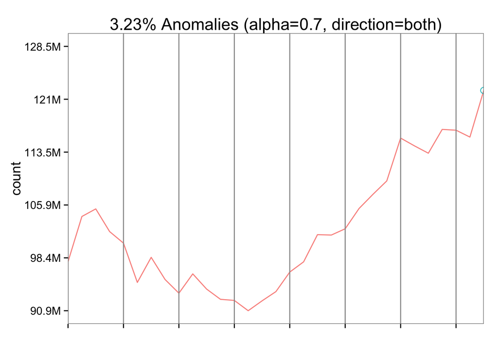

```r
library(AnomalyDetection)
res = AnomalyDetectionVec(search[,2], period=2, alpha = 0.7, direction='both', only_last=FALSE, plot=TRUE)
res$plot
```

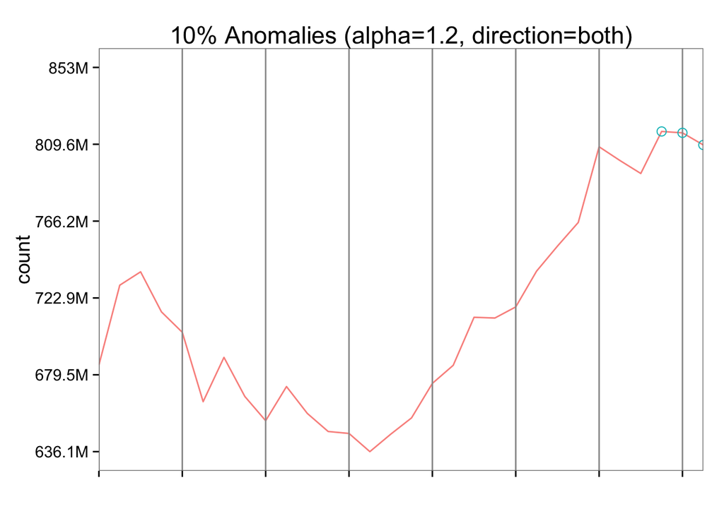

```r
res = AnomalyDetectionVec(search.week[,2], period=2, alpha = 1.2, direction='both', only_last=FALSE, plot=TRUE)
res$plot
```

Как видим, алгоритм помог нам выделить некоторые аномалии в конце рассматриваемого периода, однако его уверенность в них довольно низка, так что не стоит верить, что они точно являются аномалиями.

Собственно, еще можно построить линию треда для каждого из рядов:

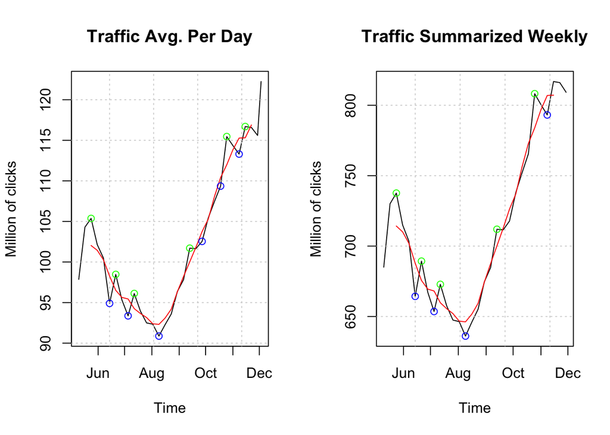

```r
par(mfrow = c(1, 2))
plot(search$Date, search$Yandex / 10^6, type = "l", xlab = "Time", ylab = "Million of clicks", main = "Traffic Avg. Per Day")
grid()
img <- filter(search$Yandex / 10^6, filter = rep(1/5, 5))
lines(search$Date, img, col = "red")
anom.pos <- c()
anom.neg <- c()
idx.pos <- c()
idx.neg <- c()
for (i in 1:length(img)) {
        if (!is.na(img[i]) && abs(img[i] - (search$Yandex[i] / 10^6)) > 1) {
            if (img[i] < search$Yandex[i] / 10^6) {
                idx.pos <- c(idx.pos, i)
                anom.pos <- c(anom.pos, search$Yandex[i] / 10^6)
            } else {
                idx.neg <- c(idx.neg, i)
                anom.neg <- c(anom.neg, search$Yandex[i] / 10^6)
            }
        }
}
points(search$Date[idx.pos], anom.pos, col = "green")
points(search$Date[idx.neg], anom.neg, col = "blue")

plot(search.week$Date, search.week$Yandex / 10^6, type = "l", xlab = "Time", ylab = "Million of clicks", main = "Traffic Summarized Weekly")
grid()
img <- filter(search.week$Yandex / 10^6, filter = rep(1/5, 5))
lines(search.week$Date, img, col = "red")
anom.pos.week <- c()
anom.neg.week <- c()
idx.pos.week <- c()
idx.neg.week <- c()
for (i in 1:length(img)) {
        if (!is.na(img[i]) && abs(img[i] - (search.week$Yandex[i] / 10^6)) > 10) {
            if (img[i] < search.week$Yandex[i] / 10^6) {
                idx.pos.week <- c(idx.pos.week, i)
                anom.pos.week <- c(anom.pos.week, search.week$Yandex[i] / 10^6)
            }
            else {
                idx.neg.week <- c(idx.neg.week, i)
                anom.neg.week <- c(anom.neg.week, search.week$Yandex[i] / 10^6)
            }
        }
}
points(search.week$Date[idx.pos.week], anom.pos.week, col = "green")
points(search.week$Date[idx.neg.week], anom.neg.week, col = "blue")
```

В качестве критерия определения аномалий было взять отклонение от линии тренда более, чем на 1 млн. переходов для среднесуточного и 10 млн. переходов для общего количества за неделю, что, возможно, довольно маленькие критерии, но все же.

Если говорить об аномалиях, как о значениях, которым слишком сильно отличаются от заданной линии тренда, то можно выделить следующие типы аномалий:

- Положительные - если значие больше ожидаемого (на какую-то константу)
- Отрицательные - если значение меньше ожидаемого (на какую-то константу)
- Существенные - если разница по модулю между реальным и ожидаемым знечениям больше константы
- Не существенные - если разница по модулю между реальным и ожидаемым знечениям меньше константы

К положительным аномалиям относятся следующие недели (указаны числа, с которых они начинаются):

```r
search$Date[idx.pos]
```

```
## [1] "2015-05-24" "2015-06-21" "2015-07-12" "2015-09-13" "2015-10-25"
## [6] "2015-11-15"
```

```r
search.week$Date[idx.pos.week]
```

```
## [1] "2015-05-24" "2015-06-21" "2015-07-12" "2015-09-13" "2015-10-25"
```

К отрицательным:

```r
search$Date[idx.neg]
```

```
## [1] "2015-06-14" "2015-07-05" "2015-08-09" "2015-09-27" "2015-10-18"
## [6] "2015-11-08"
```

```r
search.week$Date[idx.neg.week]
```

```
## [1] "2015-06-14" "2015-07-05" "2015-08-09" "2015-11-08"
```

К наиболе существенным аномалиям можно отнести три отрицательных аномалии, определнных с мая по начало августа и одну положительнуюю - последняя неделя рассматриваемого периода, когда произошел неожиданный скачок вверх.